# Ford GoBike System Data

## Preliminary wrangling

This data set includes 183412 entries about individual rides made in a bike-sharing system covering the greater San Francisco Bay area

```python
# import all packages and set plots to be embedded inline
import pandas as pd
import numpy as np
import seaborn as sns
import matplotlib.pyplot as plt
import calendar
import datetime
import math

%matplotlib inline
```

Load in the dataset into a pandas dataframe and checking its properties

```python
#Load the dataset
bike = pd.read_csv('fordgobike-tripdata.csv')
bike.head()
```

|  | duration_sec | start_time | end_time | start_station_id | start_station_name | start_station_latitude | start_station_longitude | end_station_id | end_station_name | end_station_latitude | end_station_longitude | bike_id | user_type | member_birth_year | member_gender | bike_share_for_all_trip |
| --- | --- | --- | --- | --- | --- | --- | --- | --- | --- | --- | --- | --- | --- | --- | --- | --- |
| 0 | 52185 | 2019-02-28 17:32:10.1450 | 2019-03-01 08:01:55.9750 | 21.0 | Montgomery St BART Station (Market St at 2nd St) | 37.789625 | -122.400811 | 13.0 | Commercial St at Montgomery St | 37.794231 | -122.402923 | 4902 | Customer | 1984.0 | Male | No |
| 1 | 42521 | 2019-02-28 18:53:21.7890 | 2019-03-01 06:42:03.0560 | 23.0 | The Embarcadero at Steuart St | 37.791464 | -122.391034 | 81.0 | Berry St at 4th St | 37.775880 | -122.393170 | 2535 | Customer | NaN | NaN | No |
| 2 | 61854 | 2019-02-28 12:13:13.2180 | 2019-03-01 05:24:08.1460 | 86.0 | Market St at Dolores St | 37.769305 | -122.426826 | 3.0 | Powell St BART Station (Market St at 4th St) | 37.786375 | -122.404904 | 5905 | Customer | 1972.0 | Male | No |
| 3 | 36490 | 2019-02-28 17:54:26.0100 | 2019-03-01 04:02:36.8420 | 375.0 | Grove St at Masonic Ave | 37.774836 | -122.446546 | 70.0 | Central Ave at Fell St | 37.773311 | -122.444293 | 6638 | Subscriber | 1989.0 | Other | No |
| 4 | 1585 | 2019-02-28 23:54:18.5490 | 2019-03-01 00:20:44.0740 | 7.0 | Frank H Ogawa Plaza | 37.804562 | -122.271738 | 222.0 | 10th Ave at E 15th St | 37.792714 | -122.248780 | 4898 | Subscriber | 1974.0 | Male | Yes |

```python
##Converting time from string to datetime
print(bike.shape)
print(bike.dtypes)
```

```
(183412, 16)
duration_sec                 int64
start_time                  object
end_time                    object
start_station_id           float64
start_station_name          object
start_station_latitude     float64
start_station_longitude    float64
end_station_id             float64
end_station_name            object
end_station_latitude       float64
end_station_longitude      float64
bike_id                      int64
user_type                   object
member_birth_year          float64
member_gender               object
bike_share_for_all_trip     object
dtype: object
```

```python
#Checking for duplicates
bike[bike.duplicated()].sum()
```

```
duration_sec               0.0
start_time                 0.0
end_time                   0.0
start_station_id           0.0
start_station_name         0.0
start_station_latitude     0.0
start_station_longitude    0.0
end_station_id             0.0
end_station_name           0.0
end_station_latitude       0.0
end_station_longitude      0.0
bike_id                    0.0
user_type                  0.0
member_birth_year          0.0
member_gender              0.0
bike_share_for_all_trip    0.0
dtype: float64
```

```python
#Checking for null values
bike.isna().sum()
```

```
duration_sec                  0
start_time                    0
end_time                      0
start_station_id            197
start_station_name          197
start_station_latitude        0
start_station_longitude       0
end_station_id              197
end_station_name            197
end_station_latitude          0
end_station_longitude         0
bike_id                       0
user_type                     0
member_birth_year          8265
member_gender              8265
bike_share_for_all_trip       0
dtype: int64
```

```python
#Checcking date information
bike.info()
```

```
<class 'pandas.core.frame.DataFrame'>
RangeIndex: 183412 entries, 0 to 183411
Data columns (total 16 columns):
duration_sec               183412 non-null int64
start_time                 183412 non-null object
end_time                   183412 non-null object
start_station_id           183215 non-null float64
start_station_name         183215 non-null object
start_station_latitude     183412 non-null float64
start_station_longitude    183412 non-null float64
end_station_id             183215 non-null float64
end_station_name           183215 non-null object
end_station_latitude       183412 non-null float64
end_station_longitude      183412 non-null float64
bike_id                    183412 non-null int64
user_type                  183412 non-null object
member_birth_year          175147 non-null float64
member_gender              175147 non-null object
bike_share_for_all_trip    183412 non-null object
dtypes: float64(7), int64(2), object(7)
memory usage: 22.4+ MB
```

```python
#Descriptive statistics for numeric variables
bike.describe()
```

|  | duration_sec | start_station_id | start_station_latitude | start_station_longitude | end_station_id | end_station_latitude | end_station_longitude | bike_id | member_birth_year |
| --- | --- | --- | --- | --- | --- | --- | --- | --- | --- |
| count | 183412.000000 | 183215.000000 | 183412.000000 | 183412.000000 | 183215.000000 | 183412.000000 | 183412.000000 | 183412.000000 | 175147.000000 |
| mean | 726.078435 | 138.590427 | 37.771223 | -122.352664 | 136.249123 | 37.771427 | -122.352250 | 4472.906375 | 1984.806437 |
| std | 1794.389780 | 111.778864 | 0.099581 | 0.117097 | 111.515131 | 0.099490 | 0.116673 | 1664.383394 | 10.116689 |
| min | 61.000000 | 3.000000 | 37.317298 | -122.453704 | 3.000000 | 37.317298 | -122.453704 | 11.000000 | 1878.000000 |
| 25% | 325.000000 | 47.000000 | 37.770083 | -122.412408 | 44.000000 | 37.770407 | -122.411726 | 3777.000000 | 1980.000000 |
| 50% | 514.000000 | 104.000000 | 37.780760 | -122.398285 | 100.000000 | 37.781010 | -122.398279 | 4958.000000 | 1987.000000 |
| 75% | 796.000000 | 239.000000 | 37.797280 | -122.286533 | 235.000000 | 37.797320 | -122.288045 | 5502.000000 | 1992.000000 |
| max | 85444.000000 | 398.000000 | 37.880222 | -121.874119 | 398.000000 | 37.880222 | -121.874119 | 6645.000000 | 2001.000000 |

## Data cleaning

### 1. Drop rows whose columns have missing values

```python
bike = bike.dropna(subset = ['member_gender', 'start_station_id', 'end_station_id'])
```

### 2. change trip duration variable from second to minute

```python
bike['duration_min'] = bike['duration_sec'] / 60
```

### 3. Converting time from string to datetime

```python
bike['start_time'] = pd.to_datetime(bike['start_time'])
bike['start_month_num'] =bike['start_time'].apply(lambda time: time.month)
bike['start_month_char'] = bike['start_month_num'].apply(lambda x: calendar.month_abbr[x])
bike['start_hour'] = bike["start_time"].dt.hour
```

```python
import time
```

```python
bike['day'] = bike['start_time'].dt.day_name()
```

### 4. Convert day column to ordinal category

```python
days_of_week = ['Monday', 'Tuesday', 'Wednesday', 'Thursday', 'Friday', 'Saturday',
                    'Sunday']
ordered_var = pd.api.types.CategoricalDtype(ordered = True,
                                                categories = days_of_week)
bike['day'] = bike['day'].astype(ordered_var)
```

```python
this_year = 2022
bike['age'] = this_year - bike['member_birth_year']
```

```python
bike.head(9)
```

|  | duration_sec | start_time | end_time | start_station_id | start_station_name | start_station_latitude | start_station_longitude | end_station_id | end_station_name | end_station_latitude | ... | bike_id | user_type | member_birth_year | member_gender | bike_share_for_all_trip | duration_min | start_month_num | start_month_char | day | age |
| --- | --- | --- | --- | --- | --- | --- | --- | --- | --- | --- | --- | --- | --- | --- | --- | --- | --- | --- | --- | --- | --- |
| 0 | 52185 | 2019-02-28 17:32:10.145 | 2019-03-01 08:01:55.9750 | 21.0 | Montgomery St BART Station (Market St at 2nd St) | 37.789625 | -122.400811 | 13.0 | Commercial St at Montgomery St | 37.794231 | ... | 4902 | Customer | 1984.0 | Male | No | 869.750000 | 2 | Feb | Thursday | 38.0 |
| 2 | 61854 | 2019-02-28 12:13:13.218 | 2019-03-01 05:24:08.1460 | 86.0 | Market St at Dolores St | 37.769305 | -122.426826 | 3.0 | Powell St BART Station (Market St at 4th St) | 37.786375 | ... | 5905 | Customer | 1972.0 | Male | No | 1030.900000 | 2 | Feb | Thursday | 50.0 |
| 3 | 36490 | 2019-02-28 17:54:26.010 | 2019-03-01 04:02:36.8420 | 375.0 | Grove St at Masonic Ave | 37.774836 | -122.446546 | 70.0 | Central Ave at Fell St | 37.773311 | ... | 6638 | Subscriber | 1989.0 | Other | No | 608.166667 | 2 | Feb | Thursday | 33.0 |
| 4 | 1585 | 2019-02-28 23:54:18.549 | 2019-03-01 00:20:44.0740 | 7.0 | Frank H Ogawa Plaza | 37.804562 | -122.271738 | 222.0 | 10th Ave at E 15th St | 37.792714 | ... | 4898 | Subscriber | 1974.0 | Male | Yes | 26.416667 | 2 | Feb | Thursday | 48.0 |
| 5 | 1793 | 2019-02-28 23:49:58.632 | 2019-03-01 00:19:51.7600 | 93.0 | 4th St at Mission Bay Blvd S | 37.770407 | -122.391198 | 323.0 | Broadway at Kearny | 37.798014 | ... | 5200 | Subscriber | 1959.0 | Male | No | 29.883333 | 2 | Feb | Thursday | 63.0 |
| 6 | 1147 | 2019-02-28 23:55:35.104 | 2019-03-01 00:14:42.5880 | 300.0 | Palm St at Willow St | 37.317298 | -121.884995 | 312.0 | San Jose Diridon Station | 37.329732 | ... | 3803 | Subscriber | 1983.0 | Female | No | 19.116667 | 2 | Feb | Thursday | 39.0 |
| 7 | 1615 | 2019-02-28 23:41:06.766 | 2019-03-01 00:08:02.7560 | 10.0 | Washington St at Kearny St | 37.795393 | -122.404770 | 127.0 | Valencia St at 21st St | 37.756708 | ... | 6329 | Subscriber | 1989.0 | Male | No | 26.916667 | 2 | Feb | Thursday | 33.0 |
| 8 | 1570 | 2019-02-28 23:41:48.790 | 2019-03-01 00:07:59.7150 | 10.0 | Washington St at Kearny St | 37.795393 | -122.404770 | 127.0 | Valencia St at 21st St | 37.756708 | ... | 6548 | Subscriber | 1988.0 | Other | No | 26.166667 | 2 | Feb | Thursday | 34.0 |
| 9 | 1049 | 2019-02-28 23:49:47.699 | 2019-03-01 00:07:17.0250 | 19.0 | Post St at Kearny St | 37.788975 | -122.403452 | 121.0 | Mission Playground | 37.759210 | ... | 6488 | Subscriber | 1992.0 | Male | No | 17.483333 | 2 | Feb | Thursday | 30.0 |

9 rows × 21 columns

```python
bike.info()
```

```
<class 'pandas.core.frame.DataFrame'>
Int64Index: 174952 entries, 0 to 183411
Data columns (total 21 columns):
duration_sec               174952 non-null int64
start_time                 174952 non-null datetime64[ns]
end_time                   174952 non-null object
start_station_id           174952 non-null float64
start_station_name         174952 non-null object
start_station_latitude     174952 non-null float64
start_station_longitude    174952 non-null float64
end_station_id             174952 non-null float64
end_station_name           174952 non-null object
end_station_latitude       174952 non-null float64
end_station_longitude      174952 non-null float64
bike_id                    174952 non-null int64
user_type                  174952 non-null object
member_birth_year          174952 non-null float64
member_gender              174952 non-null object
bike_share_for_all_trip    174952 non-null object
duration_min               174952 non-null float64
start_month_num            174952 non-null int64
start_month_char           174952 non-null object
day                        174952 non-null category
age                        174952 non-null float64
dtypes: category(1), datetime64[ns](1), float64(9), int64(3), object(7)
memory usage: 28.2+ MB
```

### What is the structure of your dataset?

There are 174952 bike trip information in the dataset with 21 features: duration_sec, start_time, end_time, start_station_id, startstart_station_name, start_station_latitude, start_station_longitude, end_station_id, end_station_name, end_station_latitude, end_station_longitude, bike_id, user_type, member_birth_year, member_gender, bike_share_for_all_trip, duration_min, start_month_num, start_month_char

### What is/are the main feature(s) of interest in your dataset?

Which time of day, day of the week, or month of the year the most trips were taken, time taken for average trip, the gender that drove the trip the most and correlation between subscriber and customer data a user is a subscriber or customer?

### What features in the dataset do you think will help support your investigation into your feature(s) of interest?

I expect the Caltrain or Bart stations in San Francisco will have more trips than other locations because those stations are in the center of the city and connect to other major transportations. Morning and afternoon will have more trips than night time due to rush hours. Also, I assume younger riders are more than older riders because of physical abilities

## Univariate Exploration

In this section, we're going to look at various distributions.

```python
#creating a user defined function
def countplot_II(bike,col1,col2):
    '''which inputs the values to be investigated in the x axis against counts (y axis)'''
    #set plot dimensions
    plt.figure(figsize=[14,6])
    #plot
    sns.countplot(data=bike, x=col1, hue=col2)
```

```python
base_color = sns.color_palette()[0]
```

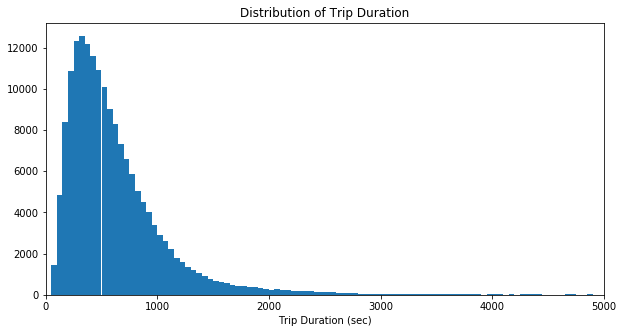

```python
# plot the distribution of trip duration
binsize = 50
bins = np.arange(0, bike['duration_sec'].max()+binsize, binsize)

plt.figure(figsize=[10, 5])
plt.hist(data = bike, x = 'duration_sec', bins = bins)
plt.xlim(0, 5000)
plt.xlabel('Trip Duration (sec)')
plt.title('Distribution of Trip Duration')
plt.show();
```

The distribution is right-skewed, with a really long tail

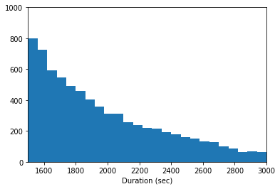

```python
binsize = 60
bins = np.arange(0, bike['duration_sec'].max()+binsize, binsize)
plt.hist(data = bike, x ='duration_sec', bins = bins)
plt.xlim(1500, 3000)
plt.ylim(0, 1000)
plt.xlabel('Duration (sec)')
plt.show();
```

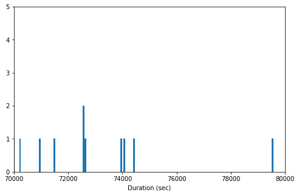

```python
binsize = 60
bins = np.arange(0, bike['duration_sec'].max()+binsize, binsize)
plt.figure(figsize=[8, 5])
plt.hist(data = bike, x ='duration_sec', bins = bins)
plt.xlim(70000, 80000)
plt.ylim(0, 5)
plt.xlabel('Duration (sec)')
plt.show();
```

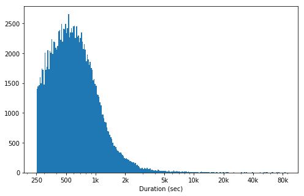

```python
# there's a long tail in the distribution, so let's put it on a log scale instead
log_binsize = 0.01
bins = 10 ** np.arange(2.4, np.log10(bike['duration_sec'].max())+log_binsize, log_binsize)
plt.figure(figsize=[8, 5])
plt.hist(data = bike, x = 'duration_sec', bins = bins)
plt.xscale('log')
plt.xticks([250, 500, 1e3, 2e3, 5e3, 1e4, 2e4, 4e4, 8e4],
           ['250', '500', '1k', '2k', '5k', '10k', '20k', '40k', '80k'])
plt.xlabel('Duration (sec)')
plt.show()
```

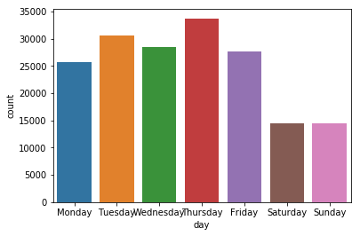

```python
sns.countplot(data=bike, x='day')
plt.show()
```

Saturday and Sunday have fewer trips compared to the rest of the days

```python
# There are some bikers with age older than 90 years old. Let's count them.
bike.query('age > 90').count()[0], bike.query('age > 100').count()[0],bike.query('age > 120').count()[0],bike.query('age > 140').count()[0]
```

```
(167, 75, 60, 1)
```

```python
# Location: there are 329 start stations.
print(len(bike['start_station_name'].value_counts()))
bike['start_station_name'].value_counts()
```

```
329
```

```
Market St at 10th St                                               3649
San Francisco Caltrain Station 2  (Townsend St at 4th St)          3408
Berry St at 4th St                                                 2952
Montgomery St BART Station (Market St at 2nd St)                   2711
Powell St BART Station (Market St at 4th St)                       2620
San Francisco Caltrain (Townsend St at 4th St)                     2577
San Francisco Ferry Building (Harry Bridges Plaza)                 2541
Howard St at Beale St                                              2216
Steuart St at Market St                                            2191
Powell St BART Station (Market St at 5th St)                       2144
The Embarcadero at Sansome St                                      1975
Bancroft Way at Telegraph Ave                                      1761
Bancroft Way at College Ave                                        1712
2nd St at Townsend St                                              1702
Beale St at Harrison St                                            1678
3rd St at Townsend St                                              1675
Embarcadero BART Station (Beale St at Market St)                   1646
4th St at Mission Bay Blvd S                                       1496
Townsend St at 7th St                                              1479
Civic Center/UN Plaza BART Station (Market St at McAllister St)    1476
The Embarcadero at Steuart St                                      1420
Downtown Berkeley BART                                             1322
Post St at Kearny St                                               1311
4th St at 16th St                                                  1274
Howard St at 8th St                                                1257
19th Street BART Station                                           1231
Esprit Park                                                        1226
Rhode Island St at 17th St                                         1224
Hearst Ave at Euclid Ave                                           1176
8th St at Brannan St                                               1154
                                                                   ...
45th St at MLK Jr Way                                                54
27th St at MLK Jr Way                                                54
Mendell St at Fairfax Ave                                            53
San Antonio Park                                                     53
Locust St at Grant St                                                49
Williams Ave at 3rd St                                               48
Delmas Ave and San Fernando St                                       47
San Carlos St at Market St                                           37
Lane St at Revere Ave                                                36
Foothill Blvd at Harrington Ave                                      35
Mission St at 1st St                                                 32
Almaden Blvd at Balbach St                                           32
George St at 1st St                                                  31
Oak St at 1st St                                                     30
Empire St at 7th St                                                  28
SAP Center                                                           27
Williams Ave at Apollo St                                            25
Foothill Blvd at 42nd Ave                                            23
San Pedro St at Hedding St                                           19
26th Ave at International Blvd                                       19
23rd Ave at Foothill Blvd                                            17
Backesto Park (Jackson St at 13th St)                                17
Leavenworth St at Broadway                                           16
Taylor St at 9th St                                                  13
Willow St at Vine St                                                  9
Farnam St at Fruitvale Ave                                            9
Parker Ave at McAllister St                                           7
21st Ave at International Blvd                                        4
Palm St at Willow St                                                  3
16th St Depot                                                         2
Name: start_station_name, Length: 329, dtype: int64
```

There are 329 start stations in this dataset.

```python
#Subset the dataset by keeping only top 5 locations with high traffics, df_top5.
star_location=['Market St at 10th St','San Francisco Caltrain Station 2  (Townsend St at 4th St)', 'Berry St at 4th St',
               'Montgomery St BART Station (Market St at 2nd St)','Powell St BART Station (Market St at 4th St)']
end_location=['San Francisco Caltrain Station 2  (Townsend St at 4th St)','Market St at 10th St',
             'Montgomery St BART Station (Market St at 2nd St)','San Francisco Ferry Building (Harry Bridges Plaza)','Powell St BART Station (Market St at 4th St)']
bike_top5_start = bike.loc[bike['start_station_name'].isin(star_location)]
bike_top5_end = bike.loc[bike['start_station_name'].isin(end_location)]
```

```python
# Test and see if only keep top 5 station
bike_top5_start['start_station_name'].value_counts()
```

```
Market St at 10th St                                         3649
San Francisco Caltrain Station 2  (Townsend St at 4th St)    3408
Berry St at 4th St                                           2952
Montgomery St BART Station (Market St at 2nd St)             2711
Powell St BART Station (Market St at 4th St)                 2620
Name: start_station_name, dtype: int64
```

```python
# Test and see if only keep top 5 station
bike_top5_end['start_station_name'].value_counts()
```

```
Market St at 10th St                                         3649
San Francisco Caltrain Station 2  (Townsend St at 4th St)    3408
Montgomery St BART Station (Market St at 2nd St)             2711
Powell St BART Station (Market St at 4th St)                 2620
San Francisco Ferry Building (Harry Bridges Plaza)           2541
Name: start_station_name, dtype: int64
```

```python
# After subsetting top 5 station with the most trip, create a countplot to see the distribution and order from top 1 to top 5
bike_top5_start_counts = bike_top5_start['start_station_name'].value_counts()
bike_top5_start_order = bike_top5_start_counts.index
bike_top5_start_order
```

```
Index(['Market St at 10th St',
       'San Francisco Caltrain Station 2  (Townsend St at 4th St)',
       'Berry St at 4th St',
       'Montgomery St BART Station (Market St at 2nd St)',
       'Powell St BART Station (Market St at 4th St)'],
      dtype='object')
```

```python
# After subsetting top 5 station with the most trip, create a countplot to see the distribution and order from top 1 to top 5
bike_top5_end_counts = bike_top5_end['start_station_name'].value_counts()
bike_top5_end_order = bike_top5_end_counts.index
bike_top5_end_order
```

```
Index(['Market St at 10th St',
       'San Francisco Caltrain Station 2  (Townsend St at 4th St)',
       'Montgomery St BART Station (Market St at 2nd St)',
       'Powell St BART Station (Market St at 4th St)',
       'San Francisco Ferry Building (Harry Bridges Plaza)'],
      dtype='object')
```

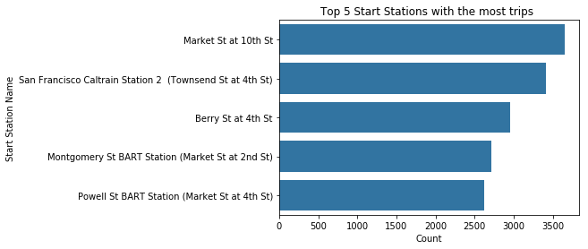

```python
#plot top 5 Start Station Name
base_color = sns.color_palette()[0]
sns.countplot(data = bike_top5_start, y='start_station_name', color=base_color, order=bike_top5_start_order)
plt.xlabel('Count')
plt.ylabel('Start Station Name')
plt.title('Top 5 Start Stations with the most trips ');
```

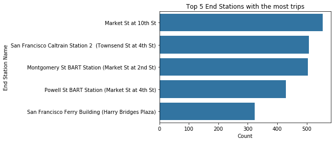

```python
#plot top 5 end Station Name
base_color = sns.color_palette()[0]
sns.countplot(data=bike_top5_end, y='end_station_name', color=base_color, order=bike_top5_end_order)
plt.xlabel('Count')
plt.ylabel('End Station Name')
plt.title('Top 5 End Stations with the most trips');
```

Transformations.

```python
bike.age.min()
```

```
21.0
```

```
Text(0.5,0,'Age (years)')
```

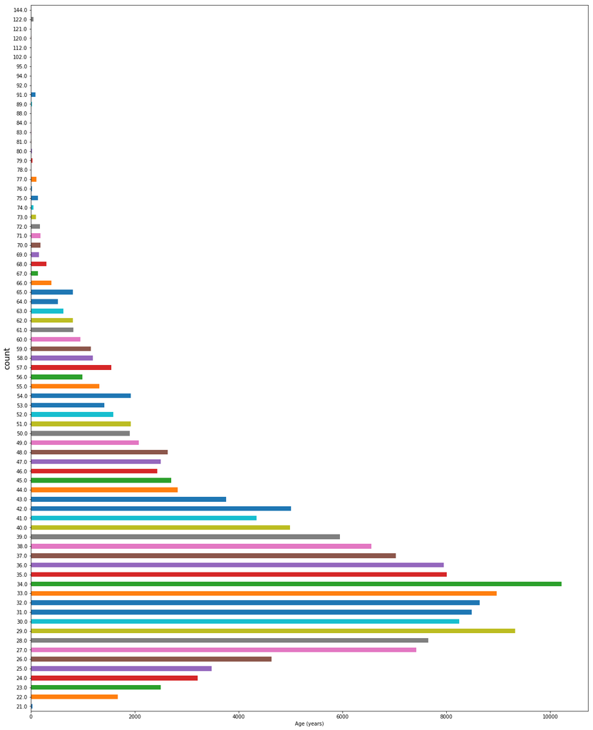

```python
plt.figure(figsize=[20,26])
bike.age.value_counts().sort_index().plot(kind='barh')
plt.yticks(fontsize=10)
plt.ylabel('count',fontsize=16)
plt.xlabel('Age (years)')
```

Passengers between age 27 and 36 are higher in number

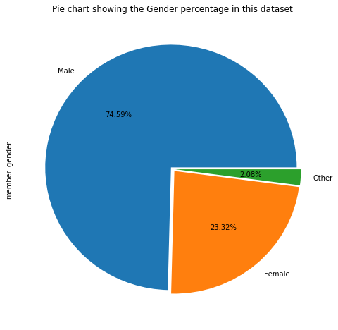

```python
bike['member_gender'].value_counts().plot(kind = 'pie',
                                              figsize = [8, 8],
                                              explode = [0.02, 0.02, 0.02],
                                              autopct = '%1.2f%%',
                                              title = 'Pie chart showing the Gender percentage in this dataset');
```

Males are higher in number compared to femals

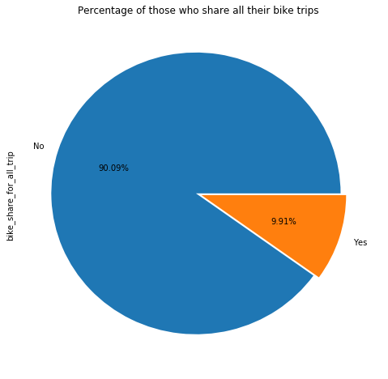

```python
bike['bike_share_for_all_trip'].value_counts().plot(kind = 'pie',
                                              figsize = [8, 8],
                                              explode = [0.02, 0.02],
                                              autopct = '%1.2f%%',
                                              title = 'Percentage of those who share all their bike trips');
```

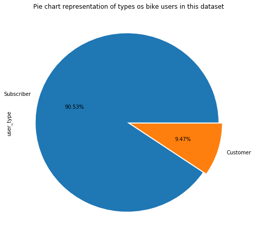

```python
bike['user_type'].value_counts().plot(kind = 'pie',
                                              figsize = [8, 8],
                                              explode = [0.02, 0.02],
                                              autopct = '%1.2f%%',
                                              title = 'Pie chart representation of types os bike users in this dataset');
```

```python
bike.columns
```

```
Index(['duration_sec', 'start_time', 'end_time', 'start_station_id',
       'start_station_name', 'start_station_latitude',
       'start_station_longitude', 'end_station_id', 'end_station_name',
       'end_station_latitude', 'end_station_longitude', 'bike_id', 'user_type',
       'member_birth_year', 'member_gender', 'bike_share_for_all_trip',
       'duration_min', 'start_month_num', 'start_month_char', 'day', 'age'],
      dtype='object')
```

## Bivariate Exploration

To start off with, I want to look at the pairwise correlations present between features in the data.

```python
# Prepare lists of numeric variables and categorical variables
numeric_vars = ['age','duration_sec']
times_chr = ['period_day','start_weekday_char','start_month_char']
users_chr = ['user_type','member_gender']
```

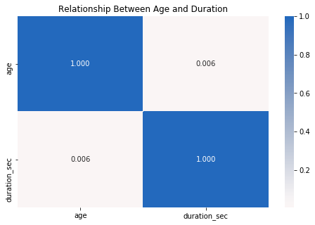

```python
#Numeric variables: correlation between age and duration second
plt.figure(figsize = [8, 5])
sns.heatmap(bike[numeric_vars].corr(), annot = True, fmt = '.3f',
           cmap = 'vlag_r', center = 0)
plt.title('Relationship Between Age and Duration');
```

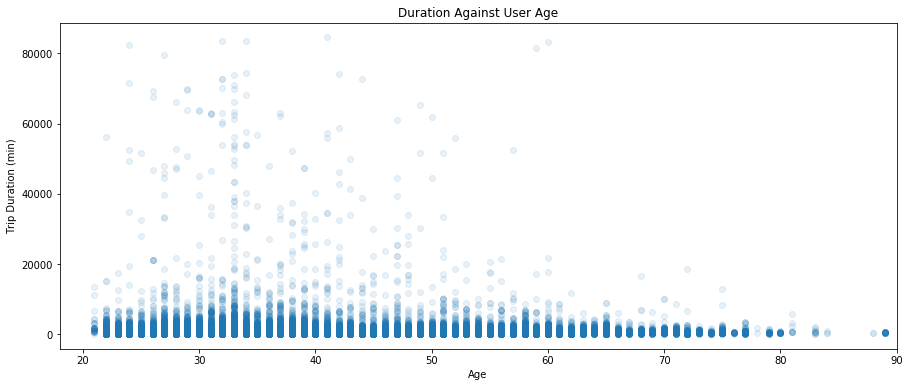

```python
#scatter plot of duration vs. age
plt.figure(figsize = [15, 6])
plt.scatter(data = bike, x = 'age', y = 'duration_sec', alpha = 1/10)
plt.xlabel('Age')
plt.xlim(18, 90)
plt.ylabel('Trip Duration (min)')
plt.title('Duration Against User Age')
plt.show()
```

Users with age of 31 and 36 seem to have the highest trip duration and as the users get older, the trip duration becomes less.

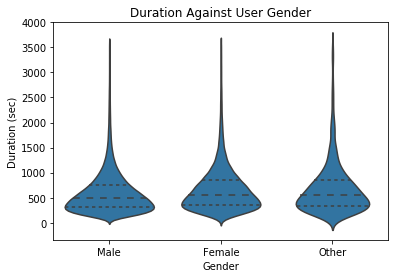

```python
# query the data for duration only below 1 hour to focus the data
bike_hour = bike.query("duration_sec < 3600")
# plot relationship between gender and duration
base_color = sns.color_palette()[0]
sns.violinplot(data=bike_hour, x='member_gender', y='duration_sec', color=base_color, inner='quartile')
plt.xlabel('Gender')
plt.ylabel('Duration (sec)')
plt.title('Duration Against User Gender');
```

[figure not shown]

```python
# Numeric variables by plotting violin plot to see the distributions:
# Top 5 stations by age,
plt.figure(figsize=(8,10))
base_color = sns.color_palette()[0]
ax = plt.subplot(211)
sns.violinplot(data=bike_top5_start, y='start_station_name', x='age', inner='quartile', color=base_color)
plt.xlabel('Age (year)')
plt.ylabel('Start Station Name')
plt.title('Age Distribution in Top 5 Stations')

ax = plt.subplot(212)
sns.violinplot(data=bike_top5_start, y='start_station_name', x='duration_sec', inner='quartile',color=base_color)
plt.xlabel('Duration (sec)')
plt.ylabel('Start Station Name')
plt.title('Duration of Trips Distribution in Top 5 Stations');
```

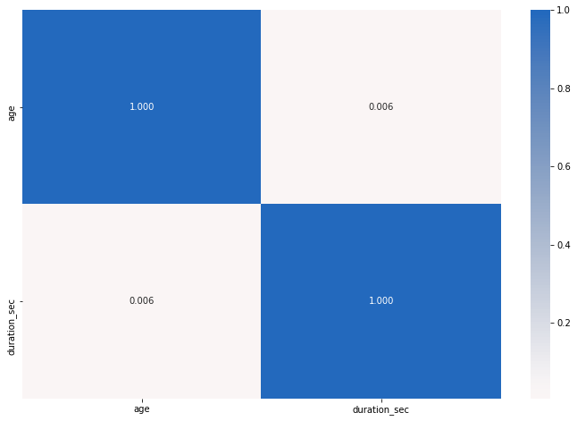

```python
# correlation plot
plt.figure(figsize = [12, 8])
sns.heatmap(bike[numeric_vars].corr(), annot = True, fmt = '.3f',
           cmap = 'vlag_r', center = 0)
plt.show()
```

The trip duration does not seem to be affected by the user gender. The violin plots look similar for these 3 gender categories, with the median all similar (around 10 minutes).

## Multivariate exploration

I would like to check for the relationship between trip duration and the age and gender of the users.

```python
# generate a new field for member age group
bike['member_age_bins'] = bike['age'].apply(lambda x: '10 - 20' if 10<x<=20
                                                  else '20 - 30' if 20<x<=30
                                                  else '30 - 40' if 30<x<=40
                                                  else '40 - 50' if 40<x<=50
                                                  else '50 - 60' if 50<x<=60
                                                  else '60 - 70' if 50<x<=70
                                                  else '70 - 80' if 50<x<=80
                                                  else '80 - 90' if 50<x<=90
                                                  else '>90' )
```

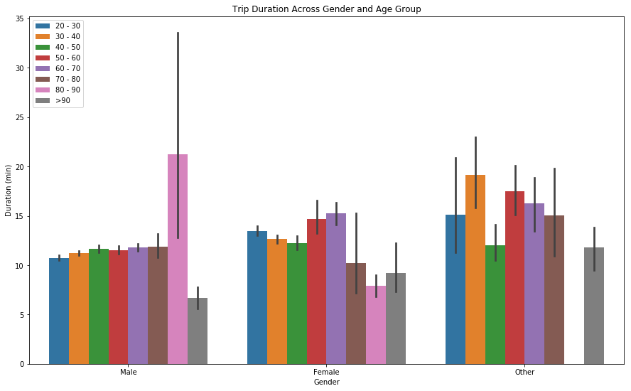

```python
# create bar plot on gender versus duration on levels of the age bins variable
plt.figure(figsize = [15, 9])

ax = sns.barplot(x='member_gender', y = 'duration_min', hue='member_age_bins', data=bike.sort_values(by= 'member_age_bins'))
plt.title('Trip Duration Across Gender and Age Group')
plt.xlabel('Gender')
plt.ylabel('Duration (min)')
leg = ax.legend()
```

```python
# Day of the week
bike['start_weekday_num'] = bike['start_time'].apply(lambda time: time.dayofweek)
dmap = {1:'Mon',2:'Tue',3:'Wed',4:'Thu',5:'Fri',6:'Sat',7:'Sun'}
bike['start_weekday_char'] = bike['start_weekday_num'].map(dmap)
```

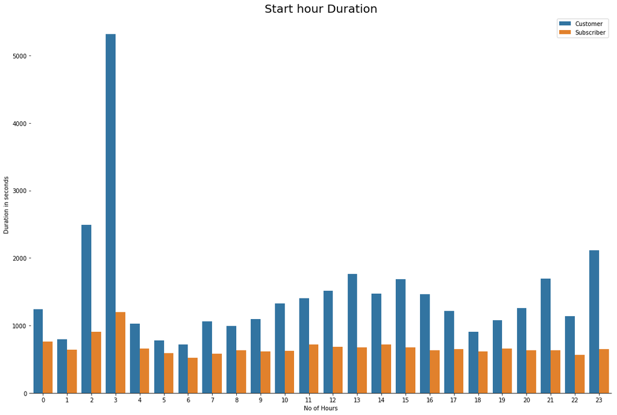

```python
plt.figure(figsize=(18, 12))
plt.title('Start hour Duration', fontsize=20)
ax = sns.barplot(data=bike, x='start_hour', y='duration_sec', hue='user_type', ci=None)

ax.set(xlabel='No of Hours', ylabel='Duration in seconds')

# Remove legend title
sns.despine(fig=None, ax=None, top=True, right=True, left=True, bottom=False, offset=None, trim=False)
plt.gca().legend().set_title('');
```

Customers had longer hours in trips than subscribers.